# Analysis on Top Radio Songs Trends

> **Columns Description**

“Peak.Rank” -> highest number in the chart the song has peaked. “Rank.lw” -> Rank Last Week “Rank.TW” -> Rank This Week

“Artist” -> person who sings the song “Title” -> Name of the song “Label” -> companies that market recorded music and corresponding videos.

“Wks.On” ->number of weeks the song has been on the Top 40 chart.

BY SPINS “peak” ->highest number of radio plays the song has gotten “TW” -> radio spins this week “LW” -> radio spins last week “Move” -> difference between last week and this week

By DAYPART “OVN” -> overnight “AMD” -> early morning  
“MID” -> mid day  
“PMD” -> afternoon  
“EVE” -> evening

“Imp.Mill.” -> how many people have listened to the song.  
“Imp.LW.Mill.” -> Impression in last Week “Imp.Move.” -> impressions movement “Imp.Rank.” -> impression rank “Imp.Rank.LW” -> impression rank last week

“StationsOn” -> number of stations a song is on “New.Stations” -> if any song is added to new station

BY MARKETS Pop/Adult Contemporary “Top.40” -> Contemporary hit radio “AC” -> Adult contemporary music “Hot.AC” -> Hot adult contemporary

Rock/Alternative/Indie “Act.Rock” -> Active Rock “Rock” -> Rock Music Market “AAA” -> Adult album alternative “Alt” -> Alternative

Urban/Rhythmic “Rhy” -> Rhythmic  
“Urban” -> Urban Music Market “Urban.AC” -> Urban adult contemporary

Country “Country” -> Country Music Market

Christian/Gospel “Gospel” -> Gospel Music Market

“Big.Pic” -> Overall Number oFMarkets

> **Installing and Loading relevant packages**

```r
require(tidyverse)
require(dplyr)
install.packages("tidyr")
library(tidyr)

install.packages("reshape2")
library(reshape2)
```

```r
install.packages("ggplot2")
library(ggplot2)
install.packages("ggalt")
library(ggalt)
install.packages("Rmisc")
library(Rmisc)  # for multiplot
install.packages("corrplot")
library(corrplot)
# for sentiment analysis
install.packages("syuzhet")
library(syuzhet)
install.packages("tidytext")
library(tidytext)
install.packages("textdata")
library(textdata)
```

# 1. **Data Analysis and Cleaning**

> **Loading our datasets**

```r
m7 <- read.csv("mediabase nov 7.csv", encoding = "UTF-8")
m11 <- read.csv("Mediabase nov 11.csv", encoding = "UTF-8")
```

> **Columns**

```r
colnames(m7)
```

```
##  [1] "Peak.Rank"    "Rank.lw"      "Rank.TW"      "Artist"       "Title"
##  [6] "Label"        "Wks.On"       "Peak"         "TW"           "LW"
## [11] "Move"         "OVN"          "AMD"          "MID"          "PMD"
## [16] "EVE"          "Imp.Mill."    "Imp.LW.Mill." "Imp.Move."    "Imp.Rank."
## [21] "Imp.Rank.LW"  "StationsOn"   "New.Stations" "Big.Pic"      "Top.40"
## [26] "Rhy"          "Urban"        "Urban.AC"     "Rock"         "AAA"
## [31] "Alt"          "Act.Rock"     "AC"           "Hot.AC"       "Country"
## [36] "Gospel"
```

```r
dim(m7)
```

```
## [1] 500  36
```

```r
dim(m11)
```

```
## [1] 500  36
```

- There are 36 columns in both datasets with similar column names

```r
# viewing a sample from our datasets
head(m7, 5)
```

|  | Peak.Rank | Rank.lw | Rank.TW | Artist | Title | Label | Wks.On | Peak | TW | LW | Move | OVN | AMD | MID | PMD | EVE | Imp.Mill. | Imp.LW.Mill. | Imp.Move. | Imp.Rank. | Imp.Rank.LW | StationsOn | New.Stations | Big.Pic | Top.40 | Rhy | Urban | Urban.AC | Rock | … |
| --- | --- | --- | --- | --- | --- | --- | --- | --- | --- | --- | --- | --- | --- | --- | --- | --- | --- | --- | --- | --- | --- | --- | --- | --- | --- | --- | --- | --- | --- | --- |
| 1 | 1 | 1 | 1 | CAPALDI, LEWIS | Someone You Loved | Vertigo/Capitol | 22 | 19038 | 17742 | 18792 | -1050 | 4567 | 2238 | 4009 | 3225 | 3703 | 82.528 | 87.806 | -5.278 | 1 | 1 | 187 | 0 | 2 | 1 | 214 | 2215 | 0 | 0 | … |
| 2 | 2 | 4 | 2 | POST MALONE | Circles | Republic | 10 | 16436 | 16436 | 15403 | 1033 | 4256 | 1983 | 3578 | 2871 | 3748 | 76.684 | 70.919 | 5.765 | 3 | 4 | 186 | 0 | 4 | 2 | 17 | 153 | 0 | 0 | … |
| 3 | 1 | 2 | 3 | LIZZO | Truth Hurts | Nice Life/Atlantic | 23 | 20012 | 16238 | 17440 | -1202 | 4082 | 2047 | 3605 | 2958 | 3546 | 80.783 | 86.200 | -5.417 | 2 | 2 | 185 | 0 | 1 | 3 | 4 | 8 | 35 | 0 | … |
| 4 | 4 | 5 | 4 | JONAS BROTHERS | Only Human | Republic | 18 | 15573 | 15573 | 14317 | 1256 | 4130 | 1894 | 3371 | 2696 | 3482 | 69.542 | 65.177 | 4.365 | 5 | 6 | 186 | 0 | 5 | 4 | 61 | 0 | 0 | 0 | … |
| 5 | 1 | 3 | 5 | MENDES, SHAWN/CABELLO, CAMILA | Senorita | Island/Epic-Republic | 19 | 19800 | 14832 | 16572 | -1740 | 3762 | 1861 | 3315 | 2709 | 3185 | 71.913 | 81.025 | -9.112 | 4 | 3 | 185 | 0 | 3 | 5 | 27 | 0 | 0 | 0 | … |

```r
head(m11, 5)
```

|  | Peak.Rank | Rank.lw | Rank.TW | Artist | Title | Label | Wks.On | Peak | TW | LW | Move | OVN | AMD | MID | PMD | EVE | Imp.Mill. | Imp.LW.Mill. | Imp.Move. | Imp.Rank. | Imp.Rank.LW | StationsOn | New.Stations | Big.Pic | Top.40 | Rhy | Urban | Urban.AC | Rock | … |
| --- | --- | --- | --- | --- | --- | --- | --- | --- | --- | --- | --- | --- | --- | --- | --- | --- | --- | --- | --- | --- | --- | --- | --- | --- | --- | --- | --- | --- | --- | --- |
| 1 | 1 | 1 | 1 | CAPALDI, LEWIS | Someone You Loved | Vertigo/Capitol | 23 | 19038 | 17296 | 17742 | -446 | 4509 | 2212 | 3880 | 3110 | 3585 | 81.776 | 82.528 | -0.752 | 1 | 1 | 186 | 0 | 1 | 1 | 313 | 2110 | 0 | 0 | … |
| 2 | 2 | 2 | 2 | POST MALONE | Circles | Republic | 11 | 17153 | 17153 | 16439 | 714 | 4485 | 2102 | 3710 | 3007 | 3849 | 79.989 | 76.687 | 3.302 | 2 | 3 | 186 | 0 | 3 | 2 | 15 | 148 | 0 | 0 | … |
| 3 | 3 | 4 | 3 | JONAS BROTHERS | Only Human | Republic | 19 | 15954 | 15954 | 15573 | 381 | 4339 | 1943 | 3443 | 2745 | 3484 | 71.373 | 69.542 | 1.831 | 5 | 5 | 186 | 0 | 5 | 3 | 58 | 0 | 0 | 0 | … |
| 4 | 4 | 7 | 4 | LIZZO | Good As Hell | Nice Life/Atlantic | 9 | 15421 | 15421 | 13290 | 2131 | 3993 | 1877 | 3370 | 2762 | 3419 | 78.619 | 68.823 | 9.796 | 3 | 6 | 186 | 0 | 7 | 4 | 12 | 140 | 1117 | 0 | … |
| 5 | 5 | 6 | 5 | SHEERAN, ED | Beautiful People f/Khalid | RCA-Atlantic | 19 | 15172 | 15172 | 14773 | 399 | 4055 | 1862 | 3276 | 2630 | 3349 | 67.644 | 66.737 | 0.907 | 6 | 7 | 186 | 0 | 6 | 5 | 49 | 0 | 897 | 0 | … |

> **Structure of the Data**

```r
str(m7)
```

```
## 'data.frame':    500 obs. of  36 variables:
##  $ Peak.Rank   : int  1 2 1 4 1 6 7 7 9 1 ...
##  $ Rank.lw     : Factor w/ 446 levels "---------","1",..: 2 292 121 329 219 369 405 383 21 3 ...
##  $ Rank.TW     : int  1 2 3 4 5 6 7 8 9 10 ...
##  $ Artist      : Factor w/ 411 levels "2 CHAINZ","21 SAVAGE",..: 61 293 220 179 249 334 220 332 343 335 ...
##  $ Title       : Factor w/ 497 levels "10,000 Hours",..: 392 89 451 326 379 45 162 447 193 200 ...
##  $ Label       : Factor w/ 240 levels "---","10 Summers/Interscope",..: 215 177 148 177 113 169 148 159 44 59 ...
##  $ Wks.On      : Factor w/ 22 levels "--","1","10",..: 13 3 14 10 11 10 21 13 8 15 ...
##  $ Peak        : int  19038 16436 20012 15573 19800 14773 13290 12993 9780 19279 ...
##  $ TW          : int  17742 16436 16238 15573 14832 14773 13290 12993 9780 9424 ...
##  $ LW          : int  18792 15403 17440 14317 16572 14179 10937 12131 9237 10367 ...
##  $ Move        : int  -1050 1033 -1202 1256 -1740 594 2353 862 543 -943 ...
##  $ OVN         : int  4567 4256 4082 4130 3762 3906 3424 3426 2688 2315 ...
##  $ AMD         : int  2238 1983 2047 1894 1861 1823 1567 1598 1070 1118 ...
##  $ MID         : int  4009 3578 3605 3371 3315 3164 2897 2903 2156 2175 ...
```

[output cut: 22 more lines]

- Looking at the structure of our dataset, we can see that
  - there are certain missing values denoted with hyphens(-), and it needs to be replaced or dropped
  - certain columns have incorrect data types, that needs to be changed

> **Correct the Data Types**

```r
m7$Rank.lw <- as.integer(as.character(m7$Rank.lw))
m7$Wks.On <- as.integer(as.character(m7$Wks.On))
m11$Rank.lw <- as.integer(as.character(m11$Rank.lw))
m11$Wks.On <- as.integer(as.character(m11$Wks.On))
```

- The missing values in Rank.lw and Wks.On has been replaced with NA.

> **Let’s first replace NA’s and hyphens**
- From a general understanding its clearly evident that the hyphen are replaced with NA data points in ‘Rank.lw’ and ‘Wks.On’. We will replace them with 0.
- And for Label hyphen should be Unknown as we dont want to drop our rows here

```r
m7$Rank.lw[is.na(m7$Rank.lw)] <- 0
m7$Wks.On[is.na(m7$Wks.On)] <- 0

m11$Rank.lw[is.na(m11$Rank.lw)] <- 0
m11$Wks.On[is.na(m11$Wks.On)] <- 0

m7$Label <- gsub('---', "Unknown", m7$Label) # replace hyphens in Label with Unknown
m11$Label <- gsub('---', "Unknown", m11$Label) # replace hyphens in Label with Unknown
```

# 2. **Descriptive Statistics**

- Summary of a data gives us the detailed information of all the variables.

```r
summary(m7)
```

```
##    Peak.Rank        Rank.lw           Rank.TW                 Artist
##  Min.   :  1.0   Min.   :   0.00   Min.   :  1.0   DABABY        :  6
##  1st Qu.: 65.0   1st Qu.:  71.75   1st Qu.:125.8   POST MALONE   :  6
##  Median :119.5   Median : 205.50   Median :250.5   BROWN, CHRIS  :  5
##  Mean   :159.7   Mean   : 276.76   Mean   :255.2   EILISH, BILLIE:  4
##  3rd Qu.:224.8   3rd Qu.: 363.75   3rd Qu.:375.2   MALUMA        :  4
##  Max.   :500.0   Max.   :1420.00   Max.   :541.0   MUSTARD       :  4
##                                                    (Other)       :471
##                             Title        Label               Wks.On
##  Joy                           :  2   Length:500         Min.   : 0.000
##  Miss Me More                  :  2   Class :character   1st Qu.: 0.000
##  Wanted                        :  2   Mode  :character   Median : 0.000
##  10,000 Hours                  :  1                      Mean   : 0.816
##  100 Bands f/Quavo/21 Savage...:  1                      3rd Qu.: 0.000
##  11:00 PM                      :  1                      Max.   :26.000
##  (Other)                       :491
##       Peak               TW                 LW                Move
##  Min.   :    2.0   Min.   :    2.00   Min.   :    0.00   Min.   :-3358.00
##  1st Qu.:   10.0   1st Qu.:    3.00   1st Qu.:    2.00   1st Qu.:   -1.00
##  Median :   45.0   Median :    7.00   Median :    6.00   Median :    1.00
##  Mean   :  704.3   Mean   :  562.05   Mean   :  544.11   Mean   :   17.94
##  3rd Qu.:  179.2   3rd Qu.:   29.25   3rd Qu.:   32.25   3rd Qu.:    3.00
##  Max.   :20012.0   Max.   :17742.00   Max.   :18792.00   Max.   : 2737.00
##
##       OVN              AMD               MID              PMD
##  Min.   :   0.0   Min.   :   0.00   Min.   :   0.0   Min.   :   0.00
##  1st Qu.:   1.0   1st Qu.:   0.00   1st Qu.:   0.0   1st Qu.:   0.00
##  Median :   3.0   Median :   0.00   Median :   0.0   Median :   1.00
##  Mean   : 168.3   Mean   :  59.52   Mean   : 109.4   Mean   :  92.14
##  3rd Qu.:  11.0   3rd Qu.:   3.00   3rd Qu.:   5.0   3rd Qu.:   4.00
##  Max.   :4567.0   Max.   :2238.00   Max.   :4009.0   Max.   :3225.00
##
##       EVE           Imp.Mill.         Imp.LW.Mill.      Imp.Move.
##  Min.   :   0.0   Min.   : 0.00000   Min.   : 0.000   Min.   :-11.62900
##  1st Qu.:   1.0   1st Qu.: 0.00300   1st Qu.: 0.001   1st Qu.: -0.00200
##  Median :   3.0   Median : 0.00900   Median : 0.008   Median :  0.00100
##  Mean   : 132.7   Mean   : 2.36893   Mean   : 2.287   Mean   :  0.08169
##  3rd Qu.:   9.0   3rd Qu.: 0.06025   3rd Qu.: 0.058   3rd Qu.:  0.00625
##  Max.   :3748.0   Max.   :82.52800   Max.   :87.806   Max.   : 13.81200
##
```

[output cut: 25 more lines]

```
##  Min.   :  0.000   Min.   :  0.000   Min.   :  0.00   Min.   :  0.000
##  1st Qu.:  0.000   1st Qu.:  0.000   1st Qu.:  0.00   1st Qu.:  0.000
##  Median :  0.000   Median :  0.000   Median :  0.00   Median :  0.000
##  Mean   :  5.756   Mean   :  6.632   Mean   : 21.42   Mean   :  2.122
##  3rd Qu.:  0.000   3rd Qu.:  0.000   3rd Qu.:  0.00   3rd Qu.:  0.000
##  Max.   :544.000   Max.   :287.000   Max.   :348.00   Max.   :531.000
##
##      Gospel
##  Min.   :  0.000
##  1st Qu.:  0.000
##  Median :  0.000
##  Mean   :  9.152
##  3rd Qu.:  0.000
##  Max.   :775.000
##
```

- Box plot on “Peak Rank” “Rank.Tw”, “Rank.Lw”

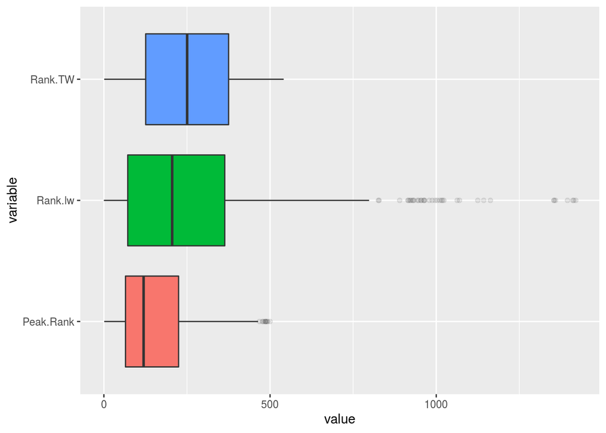

```r
ggplot(data = melt(m7[c(1:3)], id.vars = NULL), aes(x=variable, y=value)) + geom_boxplot(aes(fill=variable), outlier.alpha = 0.1) + theme(legend.position="none") + coord_flip()
```

- Box plot on “Weeks On”

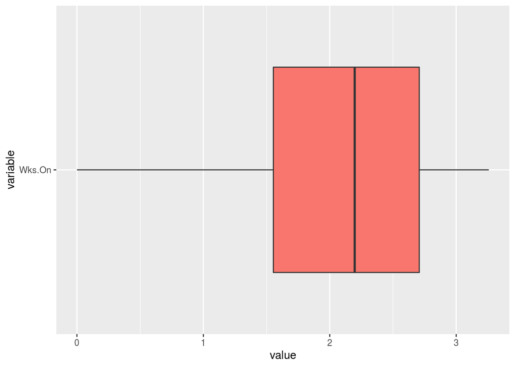

```r
ggplot(data = melt(log(m7[c(7)]), id.vars = NULL), aes(x=variable, y=value)) + geom_boxplot(aes(fill=variable), outlier.alpha = 0.1) + theme(legend.position="none") + coord_flip()
```

- Box plot on spins i.e, “Peak”, “This Week”, “Last Week”

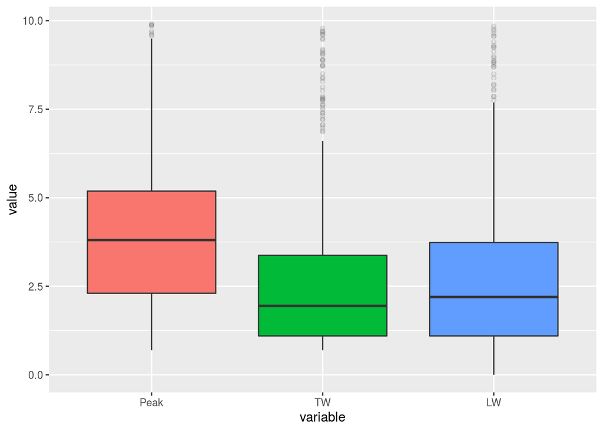

```r
ggplot(data = melt(log(m7[,c(8:10)]), id.vars = NULL), aes(x = variable, y=value)) + geom_boxplot(aes(fill = variable), outlier.alpha = 0.1) + theme(legend.position = "none")
```

- Box plot by daypart i.e, “OVN”, “am”, “mid”, “pm”, “eve”

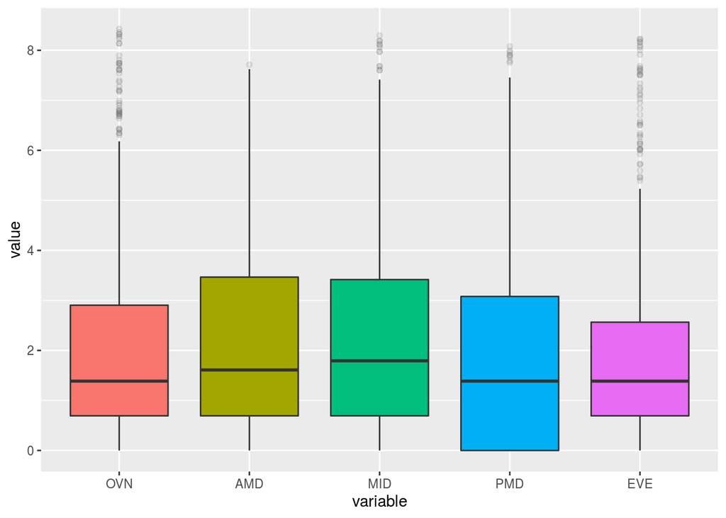

```r
ggplot(data = melt(log(m7[,c(12:16)]), id.vars = NULL), aes(x = variable, y = value)) + geom_boxplot(aes(fill = variable), outlier.alpha = 0.1) + theme(legend.position = "none")
```

- Box plot by “Format-By-Format-rank”

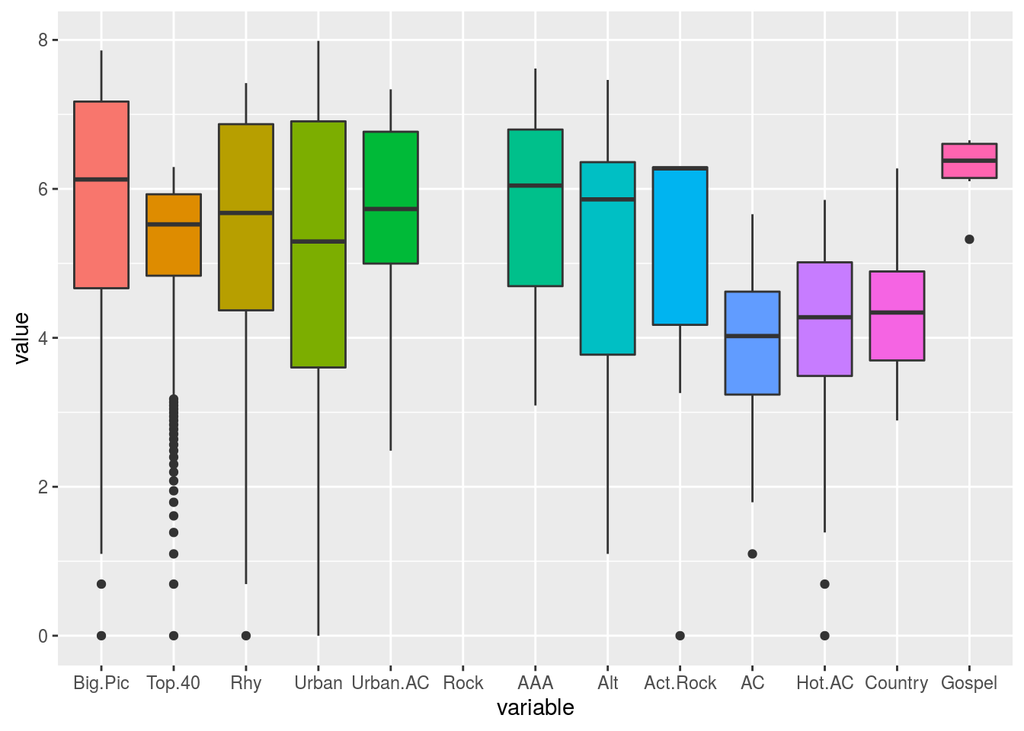

```r
ggplot(data = melt(log(m7[c(24:36)]), id.vars = NULL), aes(x = variable, y=value)) + geom_boxplot(aes(fill = variable)) + theme(legend.position = "none")
```

> **Correlation between columns**

```r
m7_num <- m7[, -(4:6)] # include every column except 4th, 5th, and 6th

m7_num$Wks.On <- gsub('--', 0, m7_num$Wks.On) # changing hypens to 0
m7_num$Rank.lw <- gsub('--', 0, m7_num$Rank.lw) # changing hypens to 0

m7_num <- as.data.frame(sapply( m7_num, as.numeric)) # converting all columns to numeric type

m7Cor <- cor(m7_num)
```

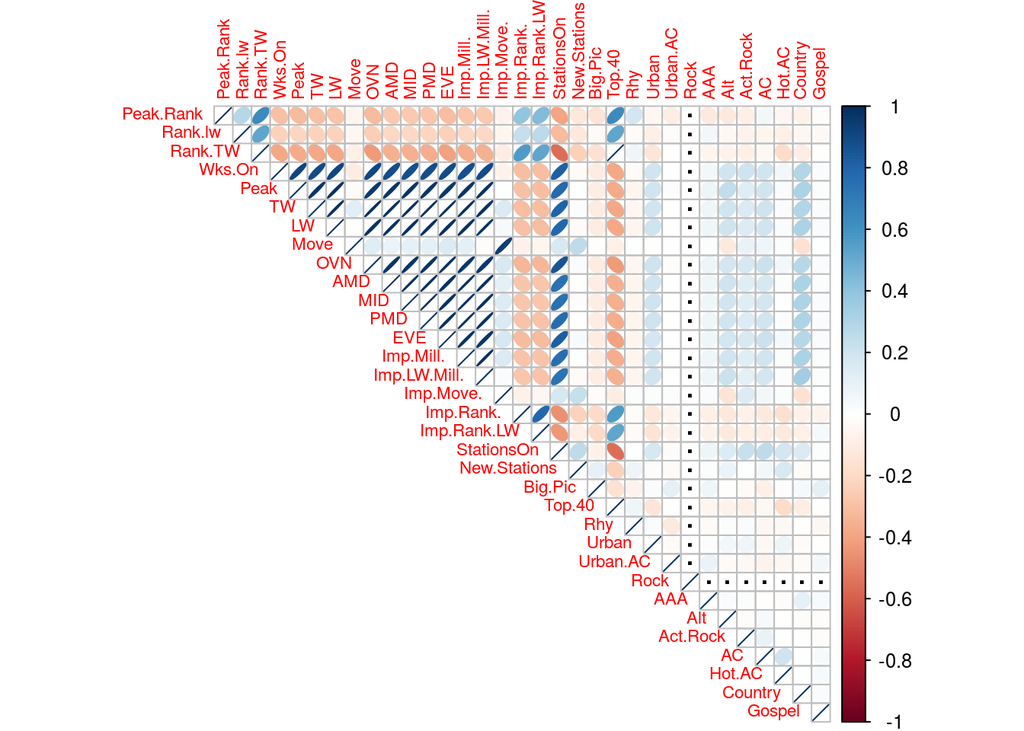

```r
corrplot(m7Cor,  type = "upper", method = "ellipse", tl.srt = 90, tl.cex = 0.7, tl.col = "red", na.label = ".")
```

- this plot gives us a correlation between numerical columns, dark blue is higl positive correlation, dark red high negative correlation
- Consider Wks.On, it is highly dependent on Peak, TW, LW, Imp.Mill, StationsOn etc
- Rank.TW is having high negative corelation with StationsOn

> **Relation between StationsOn and Rank This Week**

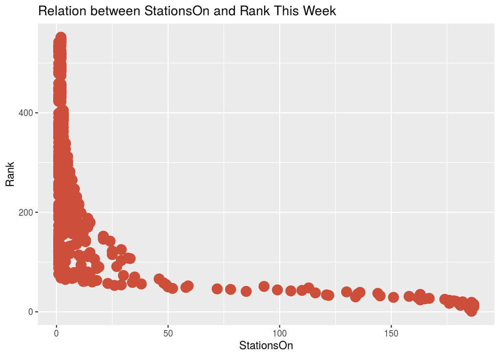

```r
ggplot(m11, aes(StationsOn, Rank.TW)) + geom_point() +
  geom_count(col="tomato3", show.legend = F)   +
  labs(y = "Rank",
       x = "StationsOn",
       title = "Relation between StationsOn and Rank This Week")
```

- This scatterplot depicts that the better the Rank higher the Number of Stations

> **Labels Relation to Peak Votes**

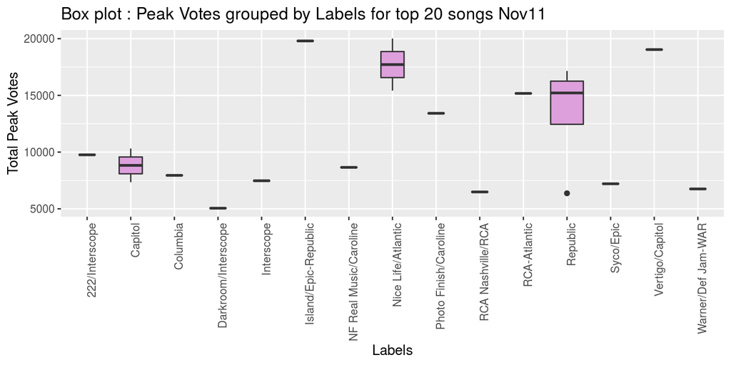

```r
ggplot(head(m11, 20), aes(Label, Peak)) + geom_boxplot(varwidth = T, fill = "plum") +
    labs(title="Box plot : Peak Votes grouped by Labels for top 20 songs Nov11",
         x = "Labels", y = "Total Peak Votes") +
theme(axis.text.x = element_text(angle = 90, hjust = 1))
```

# 3. **Exploratory Analysis**

> **Visualizing Rank change for top 20 songs between nov7 vs nov11**

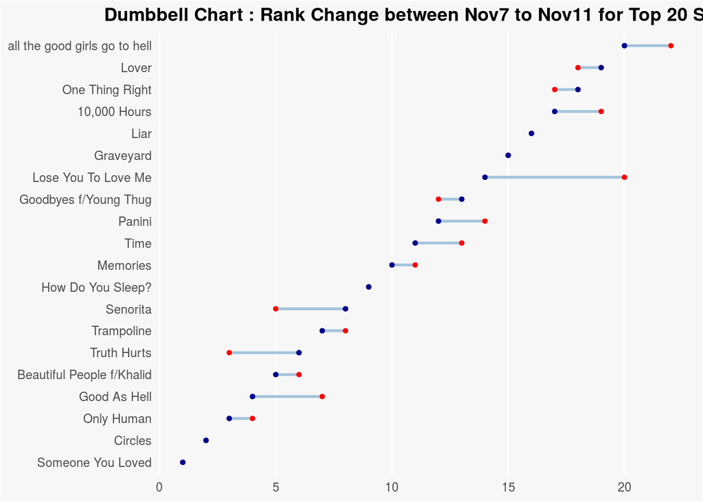

```r
m11_top20 <- head(m11, 20)
m11_top20$Title <- factor(m11_top20$Title, levels=as.character(m11_top20$Title))  # for right ordering of the dumbells

gg <- ggplot(m11_top20,aes(x = Rank.lw, xend = Rank.TW, y = Title, group = Title)) +
        geom_dumbbell(color = "#a3c4dc",
                      colour_x = "red",
                      colour_xend = "darkBlue",
                      size = 0.95) +
        labs(x = NULL,
             y = NULL,
             title = "Dumbbell Chart : Rank Change between Nov7 to Nov11 for Top 20 Songs") +
        theme(plot.title = element_text(hjust = 0.5, face = "bold"),
              plot.background = element_rect(fill = "#f7f7f7"),
              panel.background = element_rect(fill = "#f7f7f7"),
              panel.grid.minor = element_blank(),
              panel.grid.major.y = element_blank(),
              panel.grid.major.x = element_line(),
              axis.ticks = element_blank(),
              legend.position = "top",
              panel.border = element_blank())
plot(gg)
```

> **Wks.On vs Imp.Mill for Top 40 songs**

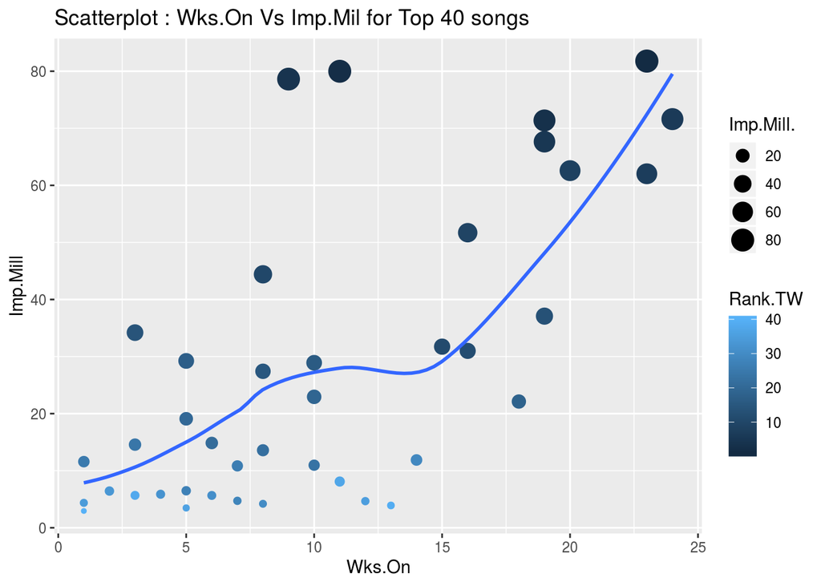

```r
# Scatterplot
ggplot(head(m11, 40), aes(x = Wks.On, y = Imp.Mill.)) +
  geom_point(aes(col = Rank.TW  , size = Imp.Mill.)) +
  geom_smooth(method="loess", se = F) +
  labs(y = "Imp.Mill",
       x = "Wks.On",
       title = "Scatterplot : Wks.On Vs Imp.Mil for Top 40 songs")
```

> **Looking closely at the Artists**
- from looking at both datasets, we can extract the ranking for 3 weeks.
- first we are going to extract the columns that we are concerned with over here

```r
m7_1 = m7[c(1, 2, 3, 4, 5, 6, 7)]
m11_1 = m11[c(1, 2, 3, 4, 5, 6, 7)]
```

- lets merge these two datasets on Artist and Title column to create a single dataframe

```r
m_1 = merge(m7_1, m11_1, by = c("Artist","Title", "Label"))
head(m_1, 5)
```

|  | Artist | Title | Label | Peak.Rank.x | Rank.lw.x | Rank.TW.x | Wks.On.x | Peak.Rank.y | Rank.lw.y | Rank.TW.y | Wks.On.y |
| --- | --- | --- | --- | --- | --- | --- | --- | --- | --- | --- | --- |
| 1 | 2 CHAINZ | Rule The World f/Ariana Grande | Def Jam | 74 | 536 | 276 | 0 | 74 | 276 | 549 | 0 |
| 2 | 21 SAVAGE | A Lot f/J Cole | Slaughter Gang/Epic | 54 | 159 | 173 | 0 | 54 | 173 | 168 | 0 |
| 3 | 24KGOLDN | Valentino | RECORDS-Columbia | 275 | 457 | 275 | 0 | 275 | 275 | 284 | 0 |
| 4 | 2XO | Blame It On You | JSound | 103 | 104 | 103 | 0 | 88 | 103 | 88 | 0 |
| 5 | 3LAU | Miss Me More | BLUME | 218 | 245 | 233 | 0 | 218 | 233 | 343 | 0 |

- We can see that we now have unnecessary columns in above dataframe, lets drop them – Peak.Rank.x - Drop as we have latest Peak.Rank.y – Rank.TW.x - Drop as we have Rank.lw.y denoting same data – Wks.On.x - Drop as we have Wks.On.y which is latest week

```r
m_1 = m_1[, -c(4, 6, 7)]
head(m_1, 5)
```

|  | Artist | Title | Label | Rank.lw.x | Peak.Rank.y | Rank.lw.y | Rank.TW.y | Wks.On.y |
| --- | --- | --- | --- | --- | --- | --- | --- | --- |
| 1 | 2 CHAINZ | Rule The World f/Ariana Grande | Def Jam | 536 | 74 | 276 | 549 | 0 |
| 2 | 21 SAVAGE | A Lot f/J Cole | Slaughter Gang/Epic | 159 | 54 | 173 | 168 | 0 |
| 3 | 24KGOLDN | Valentino | RECORDS-Columbia | 457 | 275 | 275 | 284 | 0 |
| 4 | 2XO | Blame It On You | JSound | 104 | 88 | 103 | 88 | 0 |
| 5 | 3LAU | Miss Me More | BLUME | 245 | 218 | 233 | 343 | 0 |

- in above dataframe, lets rename the columns to understand them better

```r
names(m_1)[names(m_1) == 'Rank.lw.x'] <- 'Rnk2wksBack'
names(m_1)[names(m_1) == 'Rank.lw.y'] <- 'RnkLastWk'
names(m_1)[names(m_1) == 'Rank.TW.y'] <- 'RnkTW'
names(m_1)[names(m_1) == 'Peak.Rank.y'] <- 'PeakRnk'
names(m_1)[names(m_1) == 'Wks.On.y'] <- 'WksOn'
```

```r
head(m_1, 5) # looking at sample of our new data
```

|  | Artist | Title | Label | Rnk2wksBack | PeakRnk | RnkLastWk | RnkTW | WksOn |
| --- | --- | --- | --- | --- | --- | --- | --- | --- |
| 1 | 2 CHAINZ | Rule The World f/Ariana Grande | Def Jam | 536 | 74 | 276 | 549 | 0 |
| 2 | 21 SAVAGE | A Lot f/J Cole | Slaughter Gang/Epic | 159 | 54 | 173 | 168 | 0 |
| 3 | 24KGOLDN | Valentino | RECORDS-Columbia | 457 | 275 | 275 | 284 | 0 |
| 4 | 2XO | Blame It On You | JSound | 104 | 88 | 103 | 88 | 0 |
| 5 | 3LAU | Miss Me More | BLUME | 245 | 218 | 233 | 343 | 0 |

> **Artists dominating the Top List**
- Lets determine the artists who have more than one song on this list

```r
top_artists <- m_1 %>%
    group_by(Artist)  %>%
    dplyr::summarise(n_apperance = n()) %>%
    filter(n_apperance > 1) %>%
    arrange(desc(n_apperance))
```

- in order to visualise the list in descending order we do following

```r
top_artists$Artist <- factor(top_artists$Artist, levels = top_artists$Artist[order(top_artists$n_apperance)])
```

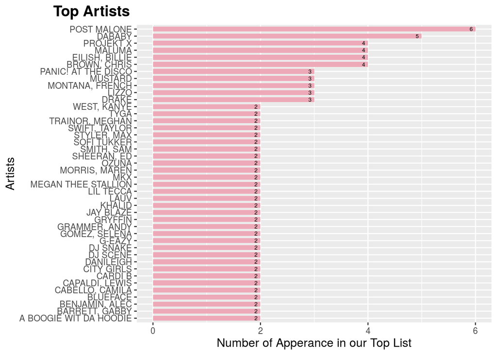

```r
ggplot(top_artists, aes(x = Artist, y = n_apperance)) +
    geom_bar(stat = "identity",  fill = "pink2", width = 0.7 ) +
    labs(title = "Top Artists", x = "Artists", y = "Number of Apperance in our Top List") +
    theme(plot.title = element_text(size=15, hjust=-.3, face = "bold"), axis.title = element_text(size=12)) +
    geom_text(aes(label=n_apperance), hjust = 2, size = 2, color = 'black') +
    coord_flip()
```

- So, it seems like Post Malone and Dababy have 6 and 5 different songs on the Top list

> **Top Artists by maximum weeks on Market**

```r
top20_by_wks_on <- m_1 %>%
group_by(Artist)  %>%
dplyr::summarise(wks_on = sum(WksOn)) %>%
arrange(desc(wks_on)) %>%
top_n(20)
top20_by_wks_on$Artist <- factor(top20_by_wks_on$Artist, levels = top20_by_wks_on$Artist [order(top20_by_wks_on$wks_on)]) # in order to visualise the list in descending order
```

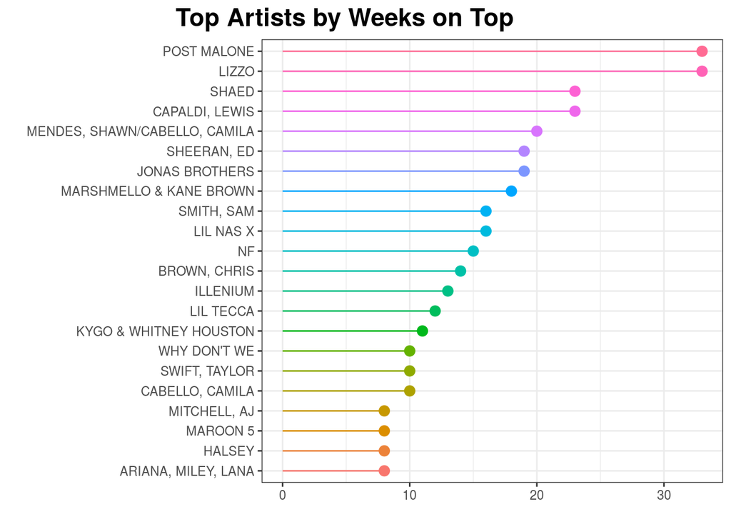

```r
ggplot(top20_by_wks_on, aes(x = Artist, y = wks_on, color = Artist)) +
    geom_point(size = 3) +
    geom_segment(aes(x = Artist, xend = Artist, y = 0, yend = wks_on)) +
    labs(title = "Top Artists by Weeks on Top", x = '', y = '') +
    theme_bw() +
    theme(legend.position = 'none', plot.title = element_text(size = 17,hjust = -0.7, face = "bold"), axis.title.y = element_text(face = "bold"), axis.title.x = element_text(angle = 120)) +
    coord_flip()
```

- Now Post Malone seems to be all on top! If we take the weeks on into consideration, Post Malone still has the top spot. But Lizzo and Shaed leapt forward now.

> **How did Post Malone’s Songs perform?**
- We would like to see how his songs perform in current rankings.

```r
post_malone <- m_1 %>% filter(Artist == "POST MALONE")

table_malone <- post_malone %>%
    group_by(`Title`) %>%
    dplyr::summarise(Rank = RnkTW) %>%
    arrange(Rank)

table_malone
```

| Title | Rank |
| --- | --- |
| Circles | 2 |
| Goodbyes f/Young Thug | 13 |
| Take What You Want | 38 |
| Enemies f/DaBaby | 75 |
| Saint Tropez | 138 |
| On The Road f/Meek, Lil Baby | 306 |

- Compare this with top rank this Artist week

```r
m_1 %>% filter(RnkTW == 1)
```

| Artist | Title | Label | Rnk2wksBack | PeakRnk | RnkLastWk | RnkTW | WksOn |
| --- | --- | --- | --- | --- | --- | --- | --- |
| CAPALDI, LEWIS | Someone You Loved | Vertigo/Capitol | 1 | 1 | 1 | 1 | 23 |

```r
capaldi_lewis <- m_1 %>% filter(Artist == "CAPALDI, LEWIS")

table_lewis <- capaldi_lewis %>%
    group_by(`Title`) %>%
    dplyr::summarise(Rank = RnkTW) %>%
    arrange(Rank)

table_lewis
```

| Title | Rank |
| --- | --- |
| Someone You Loved | 1 |
| Hold Me While You Wait | 162 |

- we can see clearly that Post Malone is really famous compared to Lewis Capaldi.

```r
post_malone
```

| Artist | Title | Label | Rnk2wksBack | PeakRnk | RnkLastWk | RnkTW | WksOn |
| --- | --- | --- | --- | --- | --- | --- | --- |
| POST MALONE | Circles | Republic | 4 | 2 | 2 | 2 | 11 |
| POST MALONE | Enemies f/DaBaby | Republic | 74 | 74 | 82 | 75 | 0 |
| POST MALONE | Goodbyes f/Young Thug | Republic | 9 | 4 | 12 | 13 | 19 |
| POST MALONE | On The Road f/Meek, Lil Baby | Republic | 296 | 182 | 286 | 306 | 0 |
| POST MALONE | Saint Tropez | Republic | 152 | 138 | 167 | 138 | 0 |
| POST MALONE | Take What You Want | Epic-Republic | 39 | 38 | 38 | 38 | 3 |

- Lets plot this data

```r
post_malone_1 <- post_malone[c(2, 4, 6, 7)]
post_malone_1
```

| Title | Rnk2wksBack | RnkLastWk | RnkTW |
| --- | --- | --- | --- |
| Circles | 4 | 2 | 2 |
| Enemies f/DaBaby | 74 | 82 | 75 |
| Goodbyes f/Young Thug | 9 | 12 | 13 |
| On The Road f/Meek, Lil Baby | 296 | 286 | 306 |
| Saint Tropez | 152 | 167 | 138 |
| Take What You Want | 39 | 38 | 38 |

```r
table_malone_1 <-  melt(post_malone_1, id.vars=c("Title"))
table_malone_1
```

| Title | variable | value |
| --- | --- | --- |
| Circles | Rnk2wksBack | 4 |
| Enemies f/DaBaby | Rnk2wksBack | 74 |
| Goodbyes f/Young Thug | Rnk2wksBack | 9 |
| On The Road f/Meek, Lil Baby | Rnk2wksBack | 296 |
| Saint Tropez | Rnk2wksBack | 152 |
| Take What You Want | Rnk2wksBack | 39 |
| Circles | RnkLastWk | 2 |
| Enemies f/DaBaby | RnkLastWk | 82 |
| Goodbyes f/Young Thug | RnkLastWk | 12 |
| On The Road f/Meek, Lil Baby | RnkLastWk | 286 |

[output cut: 8 more lines]

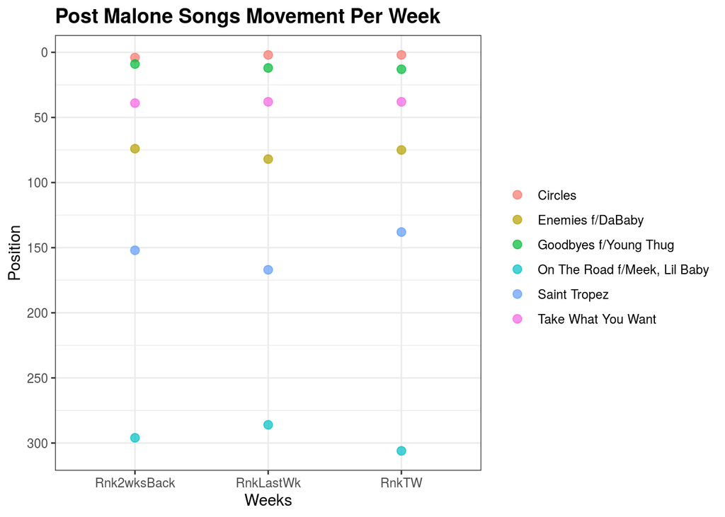

```r
table_malone_1 %>%
    ggplot(aes(x = variable, y = value, col = `Title`)) +
    geom_point(alpha = 0.7, size = 2.5) +
    scale_y_reverse(breaks = seq(0, 400, 50)) +
    labs(title = "Post Malone Songs Movement Per Week", x = "Weeks", y = "Position") +
    theme_bw() +
    theme(plot.title = element_text(size = 14, face = "bold")) +
    theme(legend.title = element_blank())
```

- we can see there is not much change in the positions in the past weeks for Post Malone

# 4. **Sentiment analysis**

- We will first find out the overall sentiment via nrc method of syuzhet package. The following code will generate the positive and negative polarity along with associated emotions.

```r
songs_titles <- as.data.frame(as.matrix(m11$Title), stringsAsFactors = F)$V1 # extracting only Title by converting column from factor to character data type

#Removing punctations and alphanumeric content
songs_titles<- gsub('[[:punct:]]+', '', songs_titles) # remove all punctuations
songs_titles<- gsub("([[:alpha:]])\1+", "", songs_titles)
songs_titles <- gsub('[[:digit:]]+', '', songs_titles) # remove all digits

songs_titles <- iconv(songs_titles,"WINDOWS-1252","UTF-8") # convert encoding

# Getting the sentiment value for the lyrics
title_sentiment <- get_nrc_sentiment((songs_titles))
```

```r
# Dataframe with cumulative value of the sentiments
sentimentscores <- data.frame(colSums(title_sentiment[,]))

# Dataframe with sentiment and score as columns
names(sentimentscores) <- "Score"
sentimentscores <- cbind("sentiment" = rownames(sentimentscores), sentimentscores)
rownames(sentimentscores) <- NULL
```

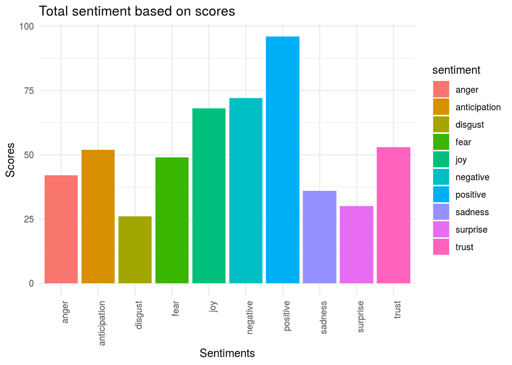

```r
# Plot for the cumulative sentiments
ggplot(data = sentimentscores, aes(x = sentiment, y = Score))+
geom_bar(aes(fill = sentiment), stat = "identity")+
theme(legend.position = "none")+
xlab("Sentiments") + ylab("Scores")+
ggtitle("Total sentiment based on scores") +
theme_minimal() +
theme(axis.text.x = element_text(angle = 90, hjust = 1))
```

- We can observe most song title have positive sentiment and are joyous
- Now that we have figured out the overall sentiment scores, we should find out which songs are closely associated with different emotions.

```r
m11_1 <- m11
m11_1$Title <- iconv(m11_1$Title,"WINDOWS-1252","UTF-8") # convert encoding
m11_1$Title <- as.character(m11_1$Title)
m11_1$Title_songs <- m11_1$Title

tidy_lyrics <- m11_1 %>% unnest_tokens(word, Title)

song_sentiment_data <- tidy_lyrics %>% inner_join(get_sentiments("nrc"), by = "word")

head(song_sentiment_data, 5)
```

|  | Peak.Rank | Rank.lw | Rank.TW | Artist | Label | Wks.On | Peak | TW | LW | Move | OVN | AMD | MID | PMD | EVE | Imp.Mill. | Imp.LW.Mill. | Imp.Move. | Imp.Rank. | Imp.Rank.LW | StationsOn | New.Stations | Big.Pic | Top.40 | Rhy | Urban | Urban.AC | Rock | AAA | … |
| --- | --- | --- | --- | --- | --- | --- | --- | --- | --- | --- | --- | --- | --- | --- | --- | --- | --- | --- | --- | --- | --- | --- | --- | --- | --- | --- | --- | --- | --- | --- |
| 1 | 4 | 7 | 4 | LIZZO | Nice Life/Atlantic | 9 | 15421 | 15421 | 13290 | 2131 | 3993 | 1877 | 3370 | 2762 | 3419 | 78.619 | 68.823 | 9.796 | 3 | 6 | 186 | 0 | 7 | 4 | 12 | 140 | 1117 | 0 | 1502 | … |
| 2 | 4 | 7 | 4 | LIZZO | Nice Life/Atlantic | 9 | 15421 | 15421 | 13290 | 2131 | 3993 | 1877 | 3370 | 2762 | 3419 | 78.619 | 68.823 | 9.796 | 3 | 6 | 186 | 0 | 7 | 4 | 12 | 140 | 1117 | 0 | 1502 | … |
| 3 | 4 | 7 | 4 | LIZZO | Nice Life/Atlantic | 9 | 15421 | 15421 | 13290 | 2131 | 3993 | 1877 | 3370 | 2762 | 3419 | 78.619 | 68.823 | 9.796 | 3 | 6 | 186 | 0 | 7 | 4 | 12 | 140 | 1117 | 0 | 1502 | … |
| 4 | 4 | 7 | 4 | LIZZO | Nice Life/Atlantic | 9 | 15421 | 15421 | 13290 | 2131 | 3993 | 1877 | 3370 | 2762 | 3419 | 78.619 | 68.823 | 9.796 | 3 | 6 | 186 | 0 | 7 | 4 | 12 | 140 | 1117 | 0 | 1502 | … |
| 5 | 4 | 7 | 4 | LIZZO | Nice Life/Atlantic | 9 | 15421 | 15421 | 13290 | 2131 | 3993 | 1877 | 3370 | 2762 | 3419 | 78.619 | 68.823 | 9.796 | 3 | 6 | 186 | 0 | 7 | 4 | 12 | 140 | 1117 | 0 | 1502 | … |

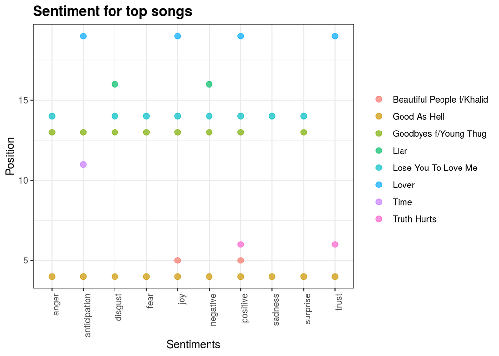

```r
subset(song_sentiment_data, Top.40 < 20) %>%
    ggplot(aes(x = sentiment, y = Rank.TW, col = `Title_songs`)) +
    geom_point(alpha = 0.7, size = 2.5) +
    labs(title = "Sentiment for top songs", x = "Sentiments", y = "Position") +
    theme_bw() +
    theme(plot.title = element_text(size = 14, face = "bold")) +
    theme(legend.title = element_blank()) +
    theme(axis.text.x = element_text(angle = 90, hjust = 1))
```

> **Rank This Week vs Sentiment**

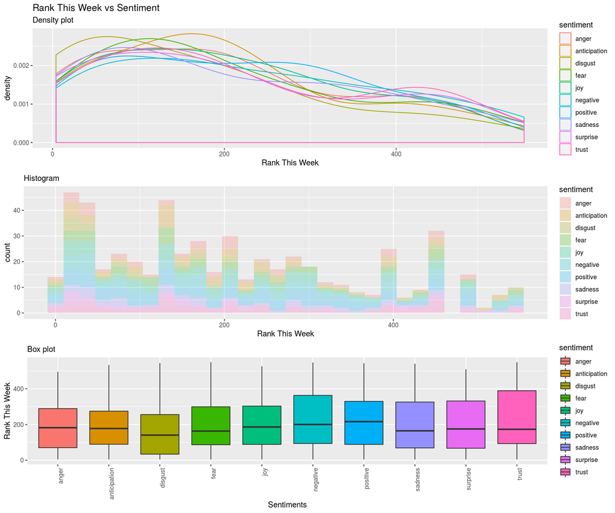

```r
p1 <- ggplot(song_sentiment_data, aes(x = Rank.TW, color = sentiment)) + geom_density(alpha = 0.25) + labs(title = "Rank This Week vs Sentiment", subtitle ="Density plot", x = "Rank This Week")
p2 <- ggplot(song_sentiment_data, aes(x = Rank.TW, fill = sentiment)) + geom_histogram(alpha = 0.25, bins = 30) + labs(subtitle ="Histogram", x = "Rank This Week")
p3 <- ggplot(song_sentiment_data, aes(x = sentiment, y = Rank.TW, fill = sentiment)) + geom_boxplot() + labs(subtitle ="Box plot ", x = "Sentiments", y = "Rank This Week") + theme(axis.text.x = element_text(angle = 90, hjust = 1))

multiplot(p1, p2, p3, cols = 1)
```

```r
top10_by_wks <- song_sentiment_data %>%
group_by(Title_songs)  %>%
dplyr::summarise(wks_on = sum(as.numeric(Wks.On))) %>%
arrange(desc(wks_on)) %>%
top_n(10)
top10_by_wks$Title_songs <- factor(top10_by_wks$Title_songs, levels = top10_by_wks$Title_songs [order(as.numeric(top10_by_wks$wks_on))]) # in order to visualise the list in descending order
```

```r
top10_by_wks
```

| Title_songs | wks_on |
| --- | --- |
| Goodbyes f/Young Thug | 152 |
| Good Things Fall...f/J.Bellion | 91 |
| Good As Hell | 90 |
| all the good girls go to hell | 50 |
| Truth Hurts | 48 |
| Don't Call Me Angel | 40 |
| Lover | 40 |
| Beautiful People f/Khalid | 38 |
| Ransom | 36 |
| No Guidance f/Drake | 28 |

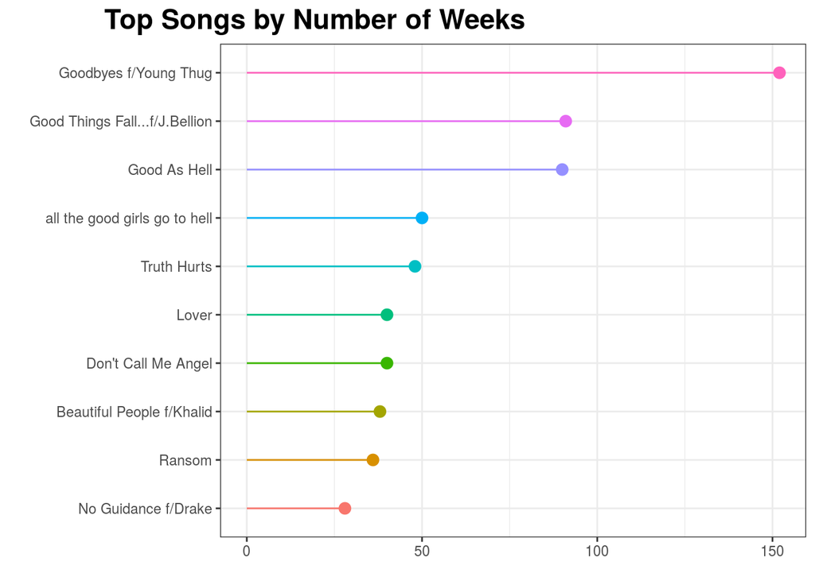

```r
ggplot(top10_by_wks, aes(x = Title_songs, y = wks_on, color = Title_songs)) +
    geom_point(size = 3) +
    geom_segment(aes(x = Title_songs, xend = Title_songs, y = 0, yend = wks_on)) +
    labs(title = "Top Songs by Number of Weeks", x = '', y = '') +
    theme_bw() +
    theme(legend.position = 'none', plot.title = element_text(size = 17,hjust = -0.7, face = "bold"), axis.title.y = element_text(face = "bold"), axis.title.x = element_text(angle = 120)) +
    coord_flip()
```

```r
top10_by_wks_full_df <- merge(top10_by_wks, song_sentiment_data, by= c("Title_songs"))
```

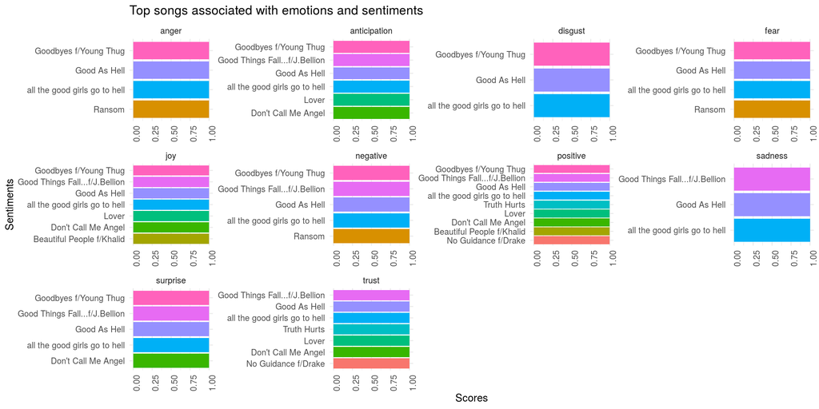

```r
top10_by_wks_full_df %>%
dplyr::count(Title_songs, sentiment, sort = TRUE) %>%
group_by(sentiment) %>%
top_n(n = 5) %>%
ggplot(aes(x = reorder(Title_songs, n), y = n, fill = Title_songs)) +
geom_bar(stat = "identity", show.legend = FALSE) +
facet_wrap(~sentiment, scales = "free") +
xlab("Sentiments") + ylab("Scores")+
ggtitle("Top songs associated with emotions and sentiments") +
coord_flip() +
theme_minimal() +
theme(axis.text.x = element_text(angle = 90, hjust = 1))
```

> **Some more analysis we want to look at**
- Relationship b/w Number of weeks and Artists Poplarity, with more weeks popularity should keep on decreasing or increasing
- do people are more inclined towards love songs - by looking at no. of weeks
- songs no more in top 500
- movement of songs who had first week last-to-last week